# Air Emissions Executive Summary

Final Project  
Data Science 1 with R (STAT 301-1)

Author

Chiemela Onuoha

Published

December 4, 2024

**Github Repo Link**

[Chiemela Onuoha’s Github (chiemelaonu)](https://github.com/stat301-1-2024-fall/final-project-1-chiemelaonu.git)

## Data source

Organisation for Economic Co-operation and Development Accessed November 21st 2024

The purpose of the report was to get a better general understanding of global air emissions and how different countries make up those emissions counts. The specific points of focus for this report were which countries have the highest emissions per quarter? Which years had the most observations? Is there a disparity in air emissions among different parts of the world? i.e. the Western world vs. other parts, etc.

## Which Countries Have the Highest Emissions per Quarter?

Table 1: Top Five Quarterly Emissions Observations

| Reference area | EMISSIONS | Observation status | UNIT_MEASURE | POLLUTANT | TIME_PERIOD | FREQ | Economic activity | ACTIVITY_SCOPE | SOURCE | Region |
| --- | --- | --- | --- | --- | --- | --- | --- | --- | --- | --- |
| United Kingdom | c(99719400, 104608900) | NA | T_CO2E | GHG | 2018-Q2 | Q | All ISIC activities | RES | ESTIMATED | Europe |
| United Kingdom | c(98975500, 104708800) | NA | T_CO2E | GHG | 2018-Q3 | Q | All ISIC activities | RES | ESTIMATED | Europe |
| United Kingdom | c(98108700, 93960900) | NA | T_CO2E | GHG | 2021-Q4 | Q | All ISIC activities | RES | ESTIMATED | Europe |
| United Kingdom | c(98008400, 103087500) | NA | T_CO2E | GHG | 2017-Q2 | Q | All ISIC activities | RES | ESTIMATED | Europe |
| United Kingdom | c(97740200, 93888500) | NA | T_CO2E | GHG | 2022-Q4 | Q | All ISIC activities | RES | ESTIMATED | Europe |

This table shows us that the United Kingdom is the country with the highest emissions per quarter.[^1]

<sup>1</sup> 2 numbers are listed in the emissions column but the first value is what I am using.

## Which Years Had the Most Observations?

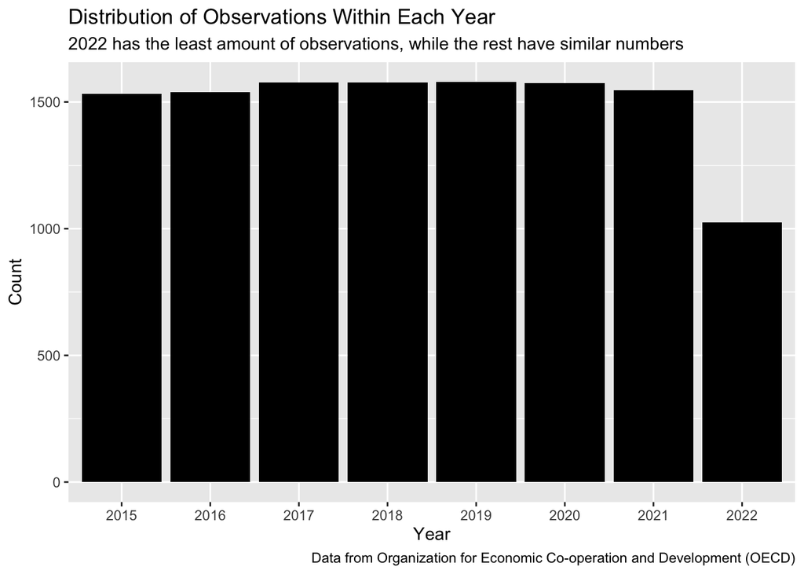

2015-2021 have about the same number of observations, but something interesting was that 2022 has a much smaller count of observations in the dataset. Unfortunately, there is no information from the dataset that says why, but it is still something to take note of.

## Is There a Disparity in Air Emissions Among Different Parts of the World?

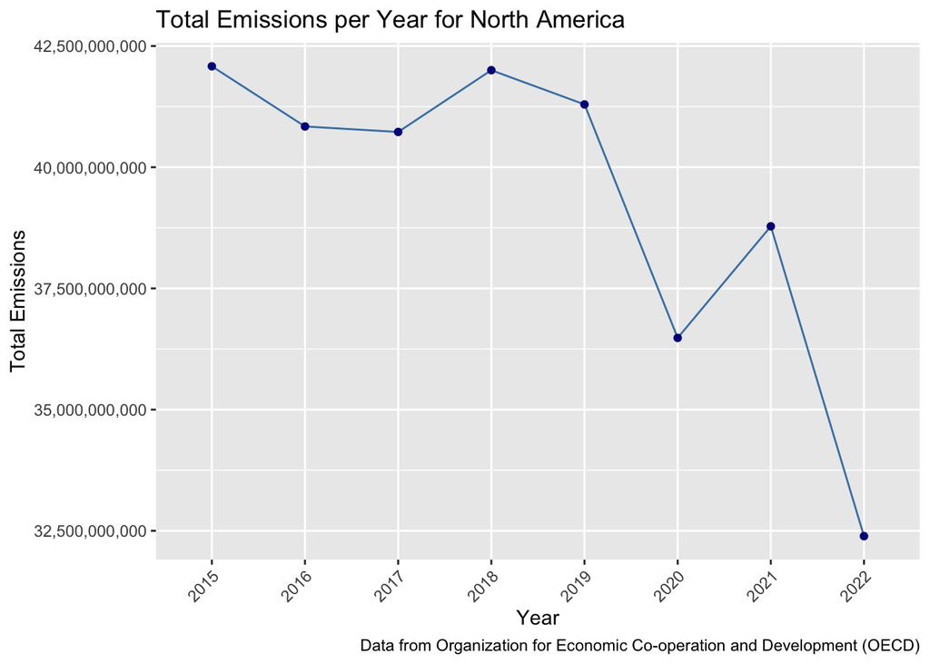

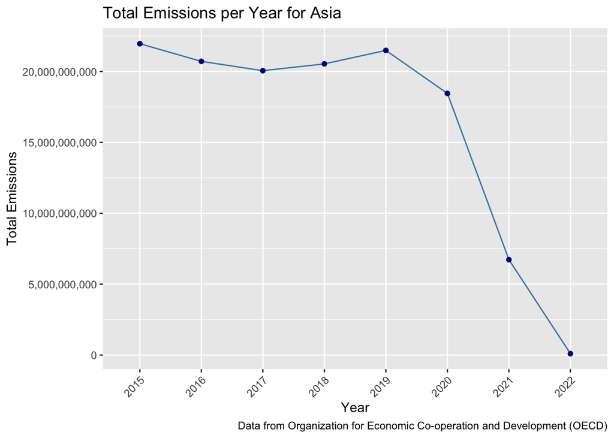

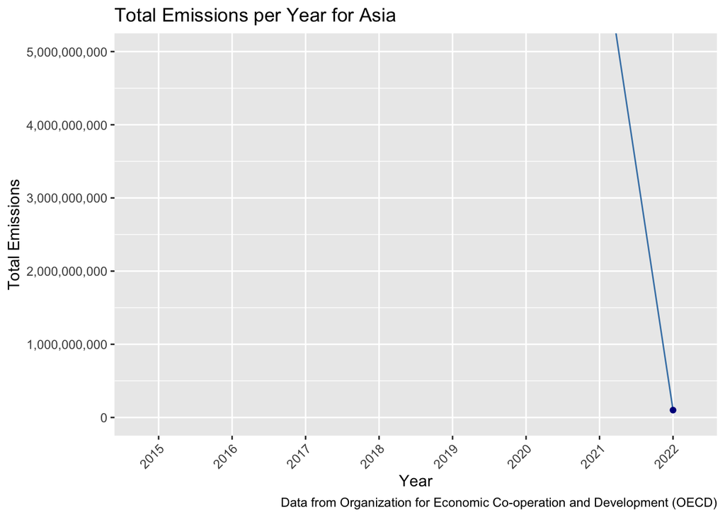

## Conclusion

The data gave me information that I have previously known through structured learning in environmental science classes, (the western world contributes a large amount to global emissions) as well as general knowledge about the environment from the news about our air emissions tendencies. What also surprised me was how the United Kingdom was the highest emitter by quarter. The data set is lacking in some background context surrounding certain observations. I do not think I could look further into why or how some things occurred, but with a data set with more columns/attributes and more preliminary information surrounding the variables, better conclusions can be made.